# Single-cell RNA seq trajctories and pseudotime plots

Stefan Filges

2020-06-11

```r
# Packages for main analysis, clustering, data structures etc.
suppressMessages(library(Seurat, quietly = TRUE))
#suppressMessages(library(mclust, quietly = TRUE))
#suppressMessages(library(biomaRt, quietly = TRUE))
#suppressMessages(library(msigdbr, quietly = TRUE))
#suppressMessages(library(clusterProfiler, quietly = TRUE))
#suppressMessages(library(destiny, quietly = TRUE))
suppressMessages(library(SummarizedExperiment, quietly = TRUE))
#suppressMessages(require(clusterExperiment, quietly = TRUE))
#suppressMessages(library(MAST, quietly = TRUE))
#suppressMessages(library(DESeq2, quietly = TRUE))
#suppressMessages(library(sctransform, quietly = TRUE))

# Packages for data handeling and plotting
#suppressMessages(library(reshape, quietly = TRUE))
#suppressMessages(library(cowplot, quietly = TRUE))
suppressMessages(library(tidyverse, quietly = TRUE))
suppressMessages(library(viridis, quietly = TRUE))
suppressMessages(library(RColorBrewer, quietly = TRUE))
#suppressMessages(library(VennDiagram, quietly = TRUE))
#suppressMessages(library(DT, quietly = TRUE))

# Packages for pseudotime ordering
suppressMessages(library(slingshot, quietly = TRUE))
suppressMessages(library(monocle, quietly = TRUE))
suppressMessages(library(SCORPIUS, quietly = TRUE))
```

# What does this document do?

This document uses pre-generated single cell data objects containing pseudotime/trajctory information and generates plots for data exploration and analysis. The data sets were generated using a different script, which can take a significant amount of time and is a long document containing code on many other issues. This document allows for faster and easier-to-use analysis.

## Load data

```r
# load object
seurat_object_save <- "~/GitHub/SingleCellScripts/data/Rdata/seurat_object_final.Rdata"
load(seurat_object_save)

# Filenames for exporting data
# cell data object containing pseudotime
cds_data <- '~/GitHub/SingleCellScripts/data/Rdata/cds_monocle2.Rdata'

# differentially expressed genes
gene_expression <- '~/GitHub/SingleCellScripts/data/gene_lists/monocle2_DEG_genes.csv'

# genes used for ordering
ordering_genes <- "~/GitHub/SingleCellScripts/data/gene_lists/ordering_genes.csv"
```

# Trajectory inference/Pseudotime ordering

There are many methods available for pseudotime ordering/trajectory inference. [Saelens et al.](https://www.nature.com/articles/s41587-019-0071-9.pdf) reviewed 45 different algorithms. They find that no algorithm works for all data sets and the best algorithm to use depends on the actual topology of the data. Therefore they recommend to test different algorithms which make slightly different assumptions and compare the results. If a result is robust across multiple tools it is most likely to be correct. The algorithms chosen below have scored high for accuracy and stability, can detect most topologies and have the highest likelihood of obtaining a top model. They also use different methods for trajectory inference (graph, tree or linear) and most require no prior knowledge about start or end points of the trajectory.

We chose three methods implemented in R:

PAGA and RaceID are graph-based, whereas slingshot and monocle use tree-based algorithms. All four have free topology inference, i.e. they don’t make prior assumptions about the underlying topology and can infer multiple types of trajectory. SCORPIUS has a fixed linear topology, i.e. the graph will always be a single line without branches. PAGA requires to set a cell population as the starting point of the trajectory, either a cluster or a sample. The others require no priors.

Implementations of all algorithms from the Saelens review can be found as docker containers with an API implemented in the [dynverse](https://dynverse.org/users/1-installation/) package.

A note on usage: PAGA, Scorpius and slingshot run very fast (seconds), wheras monocle DDRTree and RaceID requires >30 min, for a dataset with 4000 cells and 10k features. Runtimes may scale differently for each algorithm.

## Cell trajectory using slingshot

```r
scaffolds.sce <- Seurat::as.SingleCellExperiment(merged_data)

colData(scaffolds.sce)$leiden <- as.character(
  merged_data@meta.data$seurat_clusters
)
colData(scaffolds.sce)$sample <- as.character(
  merged_data@meta.data$group
)

sce <- slingshot(
  data = scaffolds.sce,
  reducedDim = 'UMAP',
  clusterLabels = 'sample'
)
```

```
## Using full covariance matrix
```

```r
col = brewer.pal(9,'Set1')[sce$sample]

colors <- colorRampPalette(brewer.pal(11,'Spectral')[-6])(100)
plotcol <- colors[cut(sce$slingPseudotime_1, breaks=100)]

pdf(file = '~/GitHub/SingleCellScripts/figures/slingshot_trajectory.pdf', width = 9, height = 6)
plot(reducedDims(sce)$UMAP, col = plotcol, pch=16, asp = 1, frame.plot=TRUE)
lines(SlingshotDataSet(sce), lwd = 3, col = 'black')
dev.off()
```

## SCORPIUS

```r
expression <- t(as.data.frame(merged_data@assays$RNA@data))
groups <- data.frame(merged_data@meta.data$group)
rownames(groups) <- rownames(merged_data@meta.data)

space <- reduce_dimensionality(
  x = expression,
  dist = 'pearson',
  ndim = 3
)

trajectory <- infer_trajectory(space)

pdf(file = '~/GitHub/SingleCellScripts/figures/scorpius_trajectory.pdf', width = 9, height = 6)
draw_trajectory_plot(
  space = space,
  progression_group = groups$merged_data,
  contour = TRUE,
  path = trajectory$path
)
dev.off()
```

## Pseudotime with Monocole 2 DDRTree

Monocle performs differential expression and time-series analysis for single-cell expression experiments. It orders individual cells according to progress through a biological process, without knowing ahead of time which genes define progress through that process. Monocle also performs differential expression analysis, clustering, visualization, and other useful tasks on single cell expression data. It is designed to work with RNA-Seq and qPCR data, but could be used with other types as well.

```r
data <- as(as.matrix(merged_data@assays$RNA@data),'sparseMatrix')
pd <- new('AnnotatedDataFrame', data=merged_data@meta.data)

fData  <- data.frame(
  gene_short_name = row.names(data),
  row.names = row.names(data)
)

fd <- new('AnnotatedDataFrame', data = fData)

scedata <- monocle::newCellDataSet(
  cellData = data,
  phenoData = pd,
  featureData = fd,
  lowerDetectionLimit = 0.5,
  expressionFamily = VGAM::negbinomial.size()
)

scedata <- estimateSizeFactors(scedata)
scedata <- estimateDispersions(scedata)

scedata<- monocle::detectGenes(scedata, min_expr = 0.1)

fData(scedata)$use_for_ordering <-
  fData(scedata)$num_cells_expressed > 0.05*ncol(scedata)


scedata <- monocle::reduceDimension(
  scedata,
  max_components = 2,
  norm_method = 'log',
  num_dim = 10,
  reduction_method = 'tSNE',
  verbose = TRUE
)

# Clustering based on density peaks
scedata <- monocle::clusterCells(
  scedata,
  verbose = FALSE
)
```

```
## Distance cutoff calculated to 3.808467
```

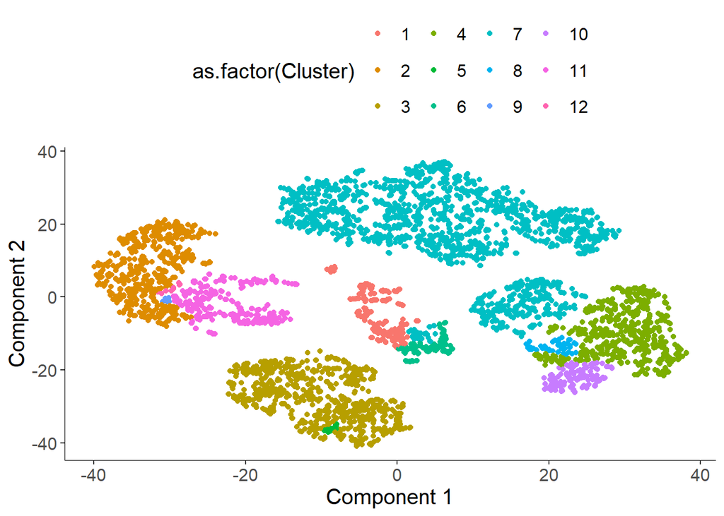

```r
# Visualize clisters
monocle::plot_cell_clusters(
  scedata,
  color_by = 'as.factor(Cluster)'
)
```

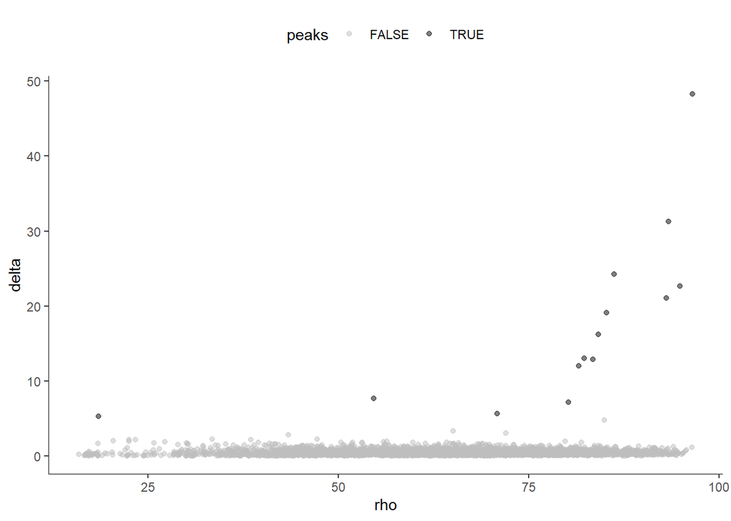

```r
# Plot the decision plot for users to  decide the threshold for defining the cell clusters.
monocle::plot_rho_delta(
  scedata,
  rho_threshold = 1,
  delta_threshold = 5
)
```

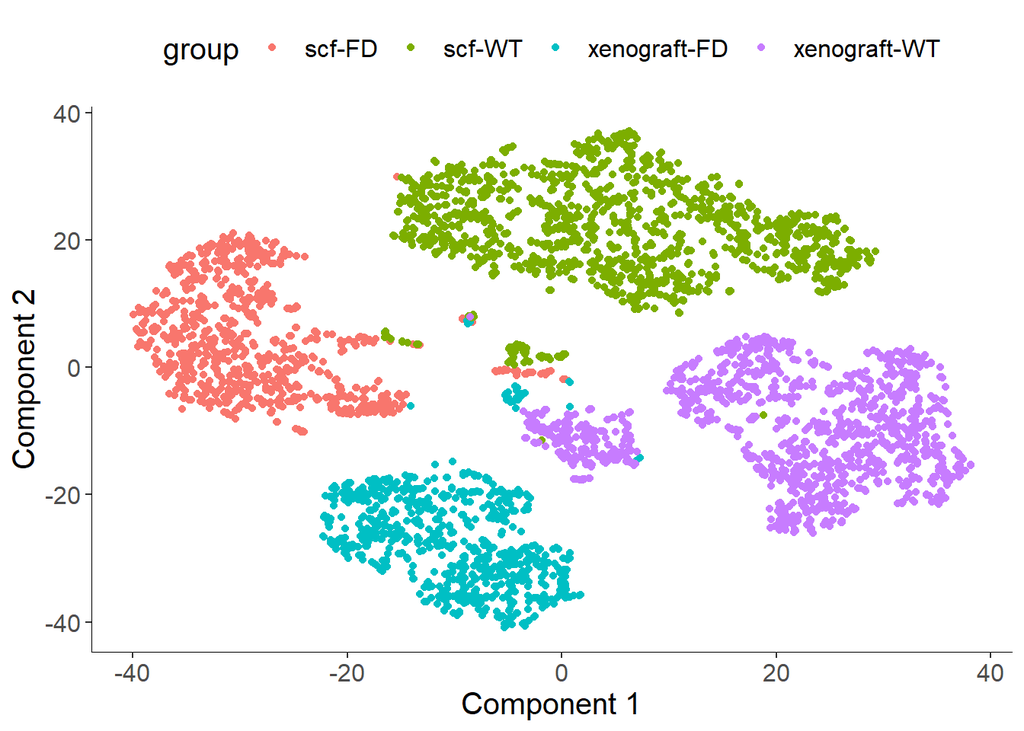

```r
# Recluster based on manually chosen parameters for Delta and Rho
scedata <- monocle::clusterCells(
  scedata,
  rho_threshold = 1,
  delta_threshold = 5,
  skip_rho_sigma = TRUE,
  verbose = FALSE
)

monocle::plot_cell_clusters(
  scedata,
  color_by = 'group'
)
```

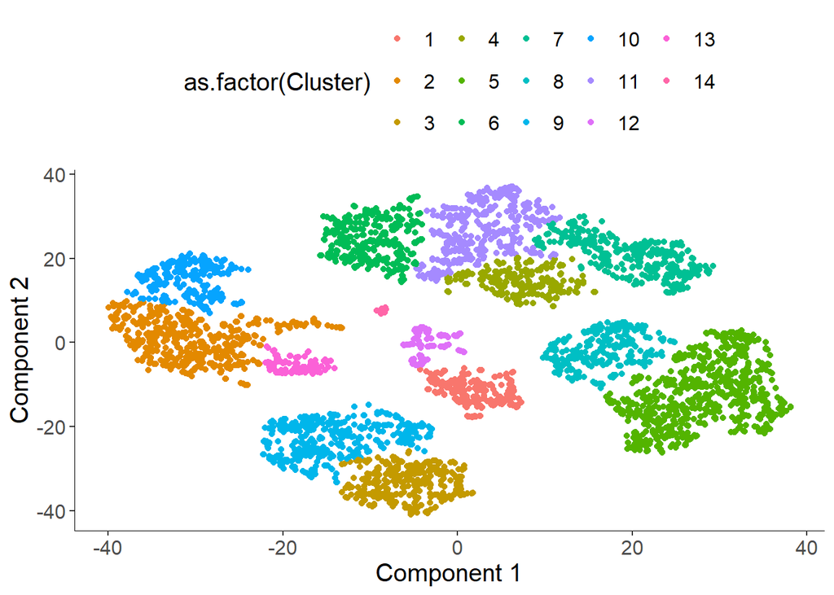

```r
monocle::plot_cell_clusters(
  scedata,
  color_by = 'as.factor(Cluster)'
)
```

```r
clustering_DEG_genes <- monocle::differentialGeneTest(
  scedata,
  fullModelFormulaStr = '~Cluster',
  cores = 2
)

# select the top 1000 significant genes as the ordering genes
scedata_ordering_genes <- row.names(clustering_DEG_genes)[order(clustering_DEG_genes$qval)][1:1000]

cds <- monocle::setOrderingFilter(
  scedata,
  ordering_genes = scedata_ordering_genes
)

cds <- monocle::reduceDimension(
  cds,
  method = 'DDRTree'
)

cds <- monocle::orderCells(cds)


# Export files
save(cds,file = cds_data)
write_csv2(clustering_DEG_genes, gene_expression)
write_csv2(data.frame(gene=scedata_ordering_genes), ordering_genes)

#cds <- monocle::orderCells(cds, root_state = GM_state(scedata))
```

## RaceID

```r
# Create the sc object
ndata <- merged_data@assays$RNA@counts

sc <- RaceID::SCseq(ndata)

# Filter for this
sc <- RaceID::filterdata(
  object = sc,
  mintotal = 2000
)

# Regress variables from cell object
vars <- data.frame(
  nCount_RNA = merged_data$nCount_RNA,
  S.score = merged_data$S.Score,
  G2M.score = merged_data$G2M.Score
)
sc <- RaceID::varRegression(sc,vars)

# Re-initialize raceID
part <- as.numeric(merged_data@meta.data$seurat_clusters)
d <- as.matrix(dist(merged_data@reductions$pca@cell.embeddings))
umap <- as.data.frame(merged_data@reductions$umap@cell.embeddings)
names(part) <- colnames(d)

n <- colnames(sc@ndata)
part <- part[n]

# partition
sc@cpart <- sc@cluster$kpart <- part
# distances
sc@distances <- d[n,n]
# umap
sc@umap <- umap[n,]
# expression data (optional)
sc@counts <- sc@counts * 0 + 1
sc@ndata  <- ndata[,n]
# cluster medoids
sc@medoids <- RaceID::compmedoids(sc, sc@cpart)

col_cluster <- colorRampPalette(
  brewer.pal(12,"Set3"))(
    length(
      unique(
        merged_data@meta.data$seurat_clusters)
      )
    )

names(col_cluster) <- as.character(unique(merged_data@meta.data$seurat_clusters))

set.seed(12345)
sc@fcol <- col_cluster[order(as.numeric(names(col_cluster)))]

# Run StemID
# Initialise lineage tree object
ltr <- RaceID::Ltree(sc)
# Compute transcriptome entropy
ltr <- RaceID::compentropy(ltr)
# Project cells unto cluster links
ltr <- RaceID::projcells(
  object = ltr,
  cthr=5,     # use clusters with at least this many cells
  nmode=TRUE, # use knn
  um=TRUE,    # use UMAP projection for visualisation
  knn=3
)

ltr <- RaceID::lineagegraph(object = ltr)

ltr <- RaceID::comppvalue(ltr, pthr=0.1)

RaceID::plotgraph(ltr,showCells=FALSE,showMap=TRUE)

x <- RaceID::compscore(ltr)

# Plot stemID score for each cluster
stem_data <- tibble(
  cluster = names(x$StemIDscore),
  score = x$StemIDscore
  ) %>%
  dplyr::arrange(score)

stem_data$cluster <- as.factor(str_remove(stem_data$cluster, "cl."))
stem_data$color <- fct_relevel(stem_data$cluster, c("10", "11", "12", "13"),
  after = Inf)

stem_score <- ggplot(
  data = stem_data,
  mapping = aes(x = reorder(cluster, score), y=score, fill = color)
  ) +
  geom_bar(
    stat = "identity",
    colour="black",
    width = .8,
    size = .01
    ) +
  theme_bw()

stem_score
```

[output not shown]